# `xyplot.cv`

X-Y plots of cross-validation results

#### Description

Plot the (average) results from (repeated) K-fold cross-validation on the y-axis against the respective models on the x-axis.

#### Usage

```
## S3 method for class 'cv'
xyplot(x, data, select = NULL,
seFactor = NA, ...)
## S3 method for class 'cvSelect'
xyplot(x, data, subset = NULL,
select = NULL, seFactor = x$seFactor, ...)
## S3 method for class 'cvTuning'
xyplot(x, data, subset = NULL,
select = NULL, seFactor = x$seFactor, ...)
```

#### Arguments

- x an object inheriting from class “cvSelect” that contains cross-validation results (note that this includes objects of class “cvTuning”). data currently ignored.
- subset a character, integer or logical vector indicating the subset of models for which to plot the cross-validation results.
- select a character, integer or logical vector indicating the columns of cross-validation results to be plotted.
- seFactor a numeric value giving the multiplication factor of the standard error for displaying error bars. Error bars can be suppressed by setting this to NA.
- … additional arguments to be passed to the “formula” method of xyplot.

#### Details

For objects with multiple columns of repeated cross-validation results, conditional plots are produced. In most situations, the default behavior is to represent the cross-validation results for each model by a vertical line segment (i.e., to call the default method of xyplot with type = “h”). However, the behavior is different for objects of class “cvTuning” with only one numeric tuning parameter. In that situation, the cross-validation results are plotted against the values of the tuning parameter as a connected line (i.e., by using type = “b”). The default behavior can of course be overridden by supplying the type argument (a full list of accepted values can be found in the help file of panel.xyplot).

#### Examples

```r
library("robustbase")
data("coleman")
set.seed(1234) # set seed for reproducibility
## set up folds for cross-validation
folds <- cvFolds(nrow(coleman), K = 5, R = 10)

## compare LS, MM and LTS regression
# perform cross-validation for an LS regression model
fitLm <- lm(Y ~ ., data = coleman)
cvFitLm <- cvLm(fitLm, cost = rtmspe,
folds = folds, trim = 0.1)
```

```r
# perform cross-validation for an MM regression model
fitLmrob <- lmrob(Y ~ ., data = coleman, k.max = 500)
cvFitLmrob <- cvLmrob(fitLmrob, cost = rtmspe,
folds = folds, trim = 0.1)
# perform cross-validation for an LTS regression model
fitLts <- ltsReg(Y ~ ., data = coleman)
cvFitLts <- cvLts(fitLts, cost = rtmspe,
folds = folds, trim = 0.1)
```

```r
# combine and plot results
cvFits <- cvSelect(LS = cvFitLm, MM = cvFitLmrob, LTS = cvFitLts)
cvFits
```

```
##
## 5-fold CV results:
##   Fit        CV
## 1  LS 1.6501492
## 2  MM 0.9872721
## 3 LTS 1.1407723
##
## Best model:
##   CV
## "MM"
```

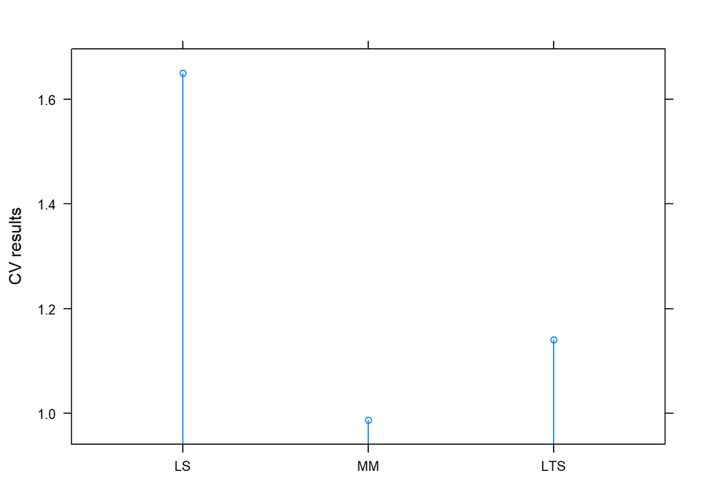

```r
xyplot(cvFits)
```

```r
## compare raw and reweighted LTS estimators for
## 50% and 75% subsets
# 50% subsets
fitLts50 <- ltsReg(Y ~ ., data = coleman, alpha = 0.5)
cvFitLts50 <- cvLts(fitLts50, cost = rtmspe, folds = folds,
fit = "both", trim = 0.1)
```

```r
# 75% subsets
fitLts75 <- ltsReg(Y ~ ., data = coleman, alpha = 0.75)
cvFitLts75 <- cvLts(fitLts75, cost = rtmspe, folds = folds,
fit = "both", trim = 0.1)
```

```r
# combine and plot results
cvFitsLts <- cvSelect("0.5" = cvFitLts50, "0.75" = cvFitLts75)
cvFitsLts
```

```
##
## 5-fold CV results:
##    Fit reweighted      raw
## 1  0.5   1.140772 1.511817
## 2 0.75   0.963192 1.165930
##
## Best model:
## reweighted        raw
##     "0.75"     "0.75"
```

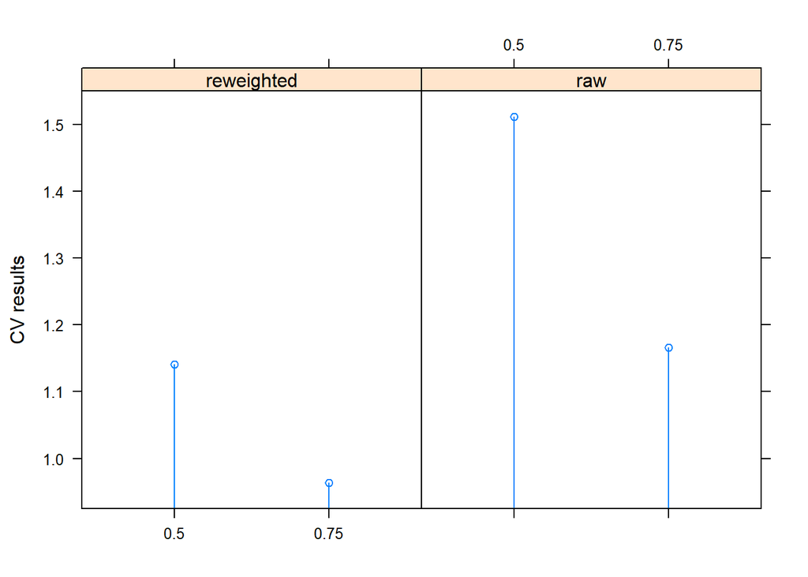

```r
xyplot(cvFitsLts)
```

```r
## evaluate MM regression models tuned for
## 80%, 85%, 90% and 95% efficiency
tuning <- list(tuning.psi=c(3.14, 3.44, 3.88, 4.68))
```

```r
# perform cross-validation
cvFitsLmrob <- cvTuning(fitLmrob$call, data = coleman,
y = coleman$Y, tuning = tuning, cost = rtmspe,
folds = folds, costArgs = list(trim = 0.1))
cvFitsLmrob
```

```
##
## 5-fold CV results:
##   tuning.psi        CV
## 1       3.14 0.9683483
## 2       3.44 0.9654850
## 3       3.88 0.9686955
## 4       4.68 0.9865426
##
## Optimal tuning parameter:
##    tuning.psi
## CV       3.44
```

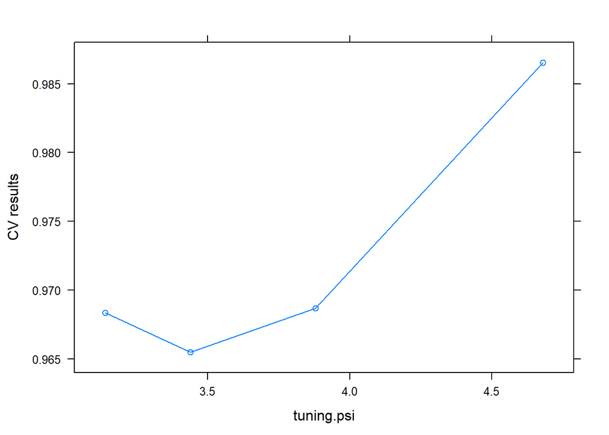

```r
# plot results
xyplot(cvFitsLmrob)
```

#### Value

An object of class “trellis” is returned invisibly. The update method can be used to update components of the object and the print method (usually called by default) will plot it on an appropriate plotting device. Author(s) Andreas Alfons See Also cvFit, cvSelect, cvTuning, plot, dotplot, bwplot, densityplot